# 15 Stochastic Modeling

Authors

Yun-Tien Lee

Alec Loudenback

> The Monte Carlo Method: (i) A last resort when doing numerical integration, and (ii) a way of wastefully using computer time. - Malvin H. Kalos[^1] (c. 1960)

## 15.1 Chapter Overview

Brief overview of stochastic modeling concepts. Random inputs vs. embedded randomness in stepwise models. Key components: distributions, time horizons, state space. Evaluating outputs with expectation, variance, and risk measures. Special properties like Markov, stationarity, and SDEs. Practical finance examples with Julia code for scenario generation and macroeconomic simulations. An overview of pseudo random number generators (PRNGs).

## 15.2 Introduction

Stochastic modeling is the technique of running many similar scenarios through a model in order to evaluate different aspects of a given model. Some contexts in which stochastic modeling arises in the financial context include:

- **Valuation**. Market consistent pricing often involves calibrating a set of stochastic economic scenarios to market-observed prices. Those calibrated scenarios are then used to determine the value of another set of contracts for which market prices are not directly observable.
- **Scenario Analysis**. Many financial models have a high degree of complexity and interactions between components not well understood *a priori*. Using a set of calibrated or otherwise arbitrary scenarios can illuminate unexpected or interrelated behavior that arises from the model. Sometimes financial assets and liabilities have a path-dependency, meaning that the overall behavior or value is a function of the entire path taken (e.g. an Asian option).
- **Risk and Capital Analysis**. Whether model parameters are point estimates (“an asset has a $1\%$ probability of default”) or distributions (“an asset has a probability of default distributed as $Beta(1,99)$”), stochastic modeling can be utilized to determine projected capital levels for a company or line of business at certain security levels.

The reliability of modeled outcomes is fundamentally dependent on the quality of both the underlying scenarios and the model framework itself. For example, if your model of interest rates produces a range of short rates that is very narrow (relative to historical values or implied volatilities), and you then run risk metrics using scenarios with unrealistically narrow short rates, you may find false comfort in the small world (Section 3.2.1) of your model.

Recall the kinds of uncertainties in Table 4.2 - stochastic modeling implementations often mechanically only address the aleatory (process) volatility component of outcome uncertainty. Through techniques like developing a posterior distribution for model parameters (Section 14.4) we can also explicitly attempt to model epistemic (parameter) uncertainty as well.

## 15.3 Fundamentals of Stochastic Modeling

Stochastic modeling explicitly incorporates randomness and uncertainty—a significant departure from deterministic approaches. First, the fundamental concepts.

### 15.3.1 Random Variables and Probability

At the core of stochastic modeling is the concept of random variables—quantities whose values depend on random outcomes. In financial contexts, random variables might represent:

- Future interest rates
- Stock price movements
- Insurance claim frequencies
- Default probabilities
- Mortality rates

These random variables are characterized by probability distributions that describe the likelihood of different outcomes. For example, stock returns might follow a normal distribution, while insurance claims might follow a Poisson distribution for frequency and a LogNormal distribution for severity.

### 15.3.2 The Role of Monte Carlo Simulation

Despite the opening quote’s humorous skepticism, **Monte Carlo methods** have become indispensable in modern financial modeling. Named after the famous casino, these techniques use repeated random sampling to obtain numerical results when analytical solutions are impractical or impossible.

The basic procedure involves:

1. Generating random inputs based on specified probability distributions
2. Running the model with these inputs
3. Collecting and analyzing the outputs
4. Repeating until sufficient samples are obtained for statistical significance

As computational power has increased, Monte Carlo methods have moved from “last resort” to standard practice in many financial applications. In addition to this conceptual chapter, Chapter 25 demonstrates this process to generate stochastic economic scenarios.

### 15.3.3 Time Dimensions in Stochastic Models

Stochastic models can be categorized based on how they treat time:

- Discrete-time models: The system evolves in distinct time steps (daily, monthly, annually)
- Continuous-time models: The system evolves continuously, often described by stochastic differential equations

Financial applications frequently use both approaches. For example, option pricing might use continuous-time models (Black-Scholes), while asset-liability management might use discrete-time models with monthly or quarterly steps.

### 15.3.4 State Spaces and Transitions

A stochastic model’s **state space** represents all possible states the system can occupy. This might be:

- Discrete: Limited number of possible states (e.g., credit ratings: AAA, AA, A, etc.)
- Continuous: Infinite possible states (e.g., stock prices can take any positive real value)

The transitions between states are governed by probability distributions or transition matrices, depending on the model type. Understanding the state space is crucial for properly formulating and solving stochastic problems in finance.

### 15.3.5 Aleatory vs Epistemic Uncertainty

Stochastic models address two fundamental types of uncertainty:

- Aleatory uncertainty: The inherent randomness in the system (e.g., market volatility)
- Epistemic uncertainty: Uncertainty due to limited knowledge about model parameters

Most basic stochastic models focus on aleatory uncertainty, assuming model parameters are known with certainty. More sophisticated approaches incorporate epistemic uncertainty by treating parameters themselves as random variables, often using Bayesian methods.

### 15.3.6 Calibration and Validation

Before a stochastic model can be applied, it must be properly calibrated to match observed data or market prices. This typically involves:

1. Establishing initial parameters via professional judgment or statistical means.
2. Adjusting parameters to match desired calibration data: e.g., minimizing a loss function with respect to the predicted outcomes versus the calibration data (see Chapter 17).
3. Validating the model against out-of-sample data.

For financial applications, models are often calibrated to be “market-consistent,” meaning they reproduce the prices of traded instruments before being used to value more complex products.

### 15.3.7 Computational Considerations

Stochastic modeling is computationally intensive, particularly when:

- Many scenarios are required for convergence
- The model has high dimensionality
- Path dependencies require storing entire trajectories

Modern implementations leverage parallel processing, variance reduction techniques, and sometimes machine learning approximations to make complex stochastic models computationally feasible.

With these fundamental concepts in mind, we can now explore specific types of stochastic models and their applications in finance and actuarial science.

### 15.3.8 Kinds of Stochastic Models

#### 15.3.8.1 Input Ensemble

In this approach, you first generate many sets of random inputs (scenarios) and then run the same model repeatedly—one run per scenario[^2]:

- **Interest Rate Scenarios for Bond Portfolios**  
  Generate thousands of yield-curve scenarios (e.g., parallel shifts, twists) to test how a bond portfolio might perform over time. By averaging the results over all simulations, you can estimate the portfolio’s expected return or risk metrics.
- **Commodity Price Paths for Hedging**  
  Create multiple possible paths for commodity prices under different macro conditions. Use these to evaluate various hedging strategies and see which one consistently mitigates risk across a wide range of market conditions.

Generally, models programmed in code can easily map across a large number of stochastic inputs.

#### 15.3.8.2 Random State

Here, the model itself “rolls the dice” at each step. Instead of pre-generating input scenarios, the randomness is embedded in the logic that evolves the state over time[^3]:

- **Property & Casualty Claims Simulation**  
  In each simulated month, randomly draw the number of claims (from a Poisson or negative binomial distribution), then randomly assign the severity of each claim (often a lognormal or gamma distribution). The insurer’s financial state (reserves, surplus) evolves based on these simulated losses.
- **Call-Center (Queueing) Model**  
  Model the random arrival of customer calls following a Poisson process, and at each arrival decide if the call is answered immediately or queued. Service times for each call can be drawn from an exponential distribution. By simulating many days, you can estimate average waiting times or the probability that a caller has to wait more than a certain threshold.

**Note**

Many financial models project outcomes using *expected values* of random variables. Many actuarial models utilize this approach to determine expected outcomes given an assumption (such as expected present value of life insurance claims). This is different than evaluating many possible discrete realized scenarios wherein each insured life either dies or survives each period, and models designed for projected expected payments need to be adapted to handle a random state approach.

#### 15.3.8.3 Closed-Form

Some stochastic processes admit analytical solutions or formulas for key quantities, so you do not need to run a simulation for each scenario. For example, here are a couple of common models that have closed form solutions to the underlying stochastic differential equation.

- **Black-Scholes Option Price**  
  The Black-Scholes formula provides an analytical price for European options despite the underlying theory being based on a stochastic evolution of asset prices. The related put-call parity is a model-free no-arbitrage relationship that holds regardless of the assumed price dynamics.
- **Ornstein-Uhlenbeck Interest Rate Model**  
  An Ornstein-Uhlenbeck process is often used to model mean-reverting interest rates. Despite being fundamentally stochastic, it has closed-form expressions for zero-coupon bond prices and other interest-rate derivatives, saving you from running thousands of random simulations for valuation.

The focus of this section will be on the other kinds of computationally driven stochastic models.

#### 15.3.8.4 Special Cases or Properties

Stochastic processes often combine several structural or theoretical properties to reflect real-world phenomena in financial and actuarial models. Before diving into each property—Markov, stationarity, martingales, and SDEs—it can be useful to see how they serve as building blocks. For example, Markov processes allow today’s decisions or valuations to depend only on the current state, whereas stationarity implies that the underlying statistical characteristics (such as mean or variance) do not change over time. Martingales capture a notion of “fairness” in gambling and risk-neutral pricing, and SDEs inject random shocks in a continuous-time setting. By understanding these properties, one can better see which assumptions are embedded in derivatives pricing, credit migration models, or mortality forecasts.

##### 15.3.8.4.1 Markov Models

A stochastic process has the Markov property if the future state depends only on the current state and not on the past states (memorylessness). Markov chains and hidden Markov models contain this property. The Markov property simplifies modeling and computation by reducing dependencies on past states. For instance, a credit rating model might assume that the probability of going from BBB to BB depends only on today’s rating, without direct reference to prior years’ ratings.

##### 15.3.8.4.2 Stationary Models

A stochastic process is stationary if its statistical properties, such as mean and variance, do not change over time. Strict stationarity means all moments of the process are time-invariant, while weak stationarity means the mean is constant, the variance is finite, and the autocovariance depends only on the lag (not on time itself). Stationarity simplifies the analysis and modeling of stochastic processes, especially for time series data. Sometimes a non-stationary model can be made stationary by transformation (such as removing a constant trend component).

##### 15.3.8.4.3 Martingales

A martingale is a stochastic process where the expected future value, given all prior information, is equal to the current value. Examples include fair gambling games or financial asset prices in efficient markets. Martingales are important in financial modeling and risk-neutral pricing, especially for derivatives.

##### 15.3.8.4.4 Stochastic Differential Equations (SDEs)

These are differential equations that incorporate stochastic terms (typically driven by Brownian motion or other noise sources). The well-known Black-Scholes equation for option pricing is one example of how SDEs can be applied in the real world. SDEs are essential for modeling systems where both deterministic and random factors drive behavior over time.

A fundamental building block of SDEs is **Brownian Motion** (also called a Wiener process). This is a continuous-time stochastic process where changes over time are independent and normally distributed. This is extensively used in financial models for asset price movements (e.g., the Black-Scholes model). In addition to financial markets, Brownian motion is also widely used in modeling physical systems (diffusion).

In practice, these properties often occur together in financial models.

### 15.3.9 Components of Stochastic Models

Stochastic modeling has additional terminology to introduce.

#### 15.3.9.1 Random variables

A random variable represents a quantity whose value is determined by the outcome of a random event. It can be discrete or continuous. It is essentially a mapping from event space to numerical values. Examples include stock prices, waiting time in queues, and number of claims in insurance. Random variables form the basis of stochastic models by introducing uncertainty into the model.

#### 15.3.9.2 Probability distributions

A probability distribution describes the likelihood of different outcomes for a random variable. Examples include Normal distribution, Poisson distribution, and Exponential distribution. Probability distributions help in modeling the behavior of random variables and in defining how likely different events or outcomes are.

#### 15.3.9.3 State space

The state space represents all possible states or values that a stochastic process can take. For example, in a Markov process, the state space might be the set of all possible values that the system can occupy at any given time. The state space helps in defining the scope of the model by specifying possible outcomes.

#### 15.3.9.4 Stochastic processes

A stochastic process is a collection of random variables indexed by time (or some other variable) that evolve in a probabilistic manner. Examples include Brownian motion, Markov chains and Poisson processes. Stochastic processes model how random variables change over time, which is essential for understanding dynamic systems influenced by randomness.

#### 15.3.9.5 Transition probabilities

These represent the probabilities of transitioning from one state to another in a stochastic process. For example, in a Markov chain, the transition matrix contains the probabilities of moving from one state to another. Transition probabilities determine how the system evolves from one time step to the next, reflecting the underlying randomness.

#### 15.3.9.6 Time horizon

The time horizon refers to the period over which the stochastic process is observed. It can be discrete (e.g., steps in a Markov chain) or continuous (e.g., continuous-time models like Brownian motion). The time horizon helps in determining how the process behaves over short or long periods.

#### 15.3.9.7 Initial conditions

These are the starting points or initial values of the random variables or the system at time zero. They may be the initial price of a stock, the initial number of customers in a queue, etc. The starting condition influences the future evolution of the process, and different initial conditions can lead to different outcomes.

#### 15.3.9.8 Noise (random shocks)

Random noise represents unpredictable random fluctuations that can affect the outcome of a stochastic process. This can be market volatility, measurement errors, or environmental variations. Noise is a critical element in stochastic models as it introduces randomness and uncertainty into otherwise deterministic systems.

## 15.4 Evaluating and Applying Stochastic Models

### 15.4.1 Evaluating Stochastic Results

These types of models are evaluated simply by running them many times until the measure of interest converges on a stable result: for example, we might run a model until the mean of the results no longer varies materially as we add more scenarios.

In practice, we watch the **standard error** of the estimate,
$$\text{SE}(\hat{\mu}) = \frac{s}{\sqrt{N}},$$
where $s$ is the sample standard deviation and $N$ is the scenario count. Doubling accuracy therefore requires roughly four times as many runs. Plotting running estimates (mean, VaR, CTE) versus scenario count is an easy convergence diagnostic; once the curve flattens relative to your materiality threshold, stop the Monte Carlo.

#### 15.4.1.1 Expectation and variance

The expected value (mean) represents the average or mean outcome of a random variable over many trials or realizations. The variance measures the spread or variability of outcomes around the expected value. These statistical measures provide insights into the central tendency and the uncertainty or risk in a stochastic model.

#### 15.4.1.2 Covariance and correlation

Covariance measures how two random variables change together. Positive covariance indicates that the variables tend to increase together. Correlation is the standardized version of covariance that measures the strength of the linear relationship between two variables. Understanding how different random variables interact helps in building more complex models, especially in multivariate stochastic processes.

#### 15.4.1.3 Risk Measures

Risk measures encompass the set of functions that map a set of outcomes to an output value characterizing the associated riskiness of those outcomes. As is usual when attempting to compress information (e.g., condensing information into a single value), there are multiple ways we can characterize this riskiness.

##### 15.4.1.3.1 Coherence & Other Desirable Properties

Further, it is desirable that a risk measure has certain properties, and risk measures that meet the first four criteria are called “coherent” in the literature. In “An Introduction to Risk Measures for Actuarial Applications” (Hardy 2006), Hardy describes four properties. Using $H$ as a risk measure and $X$ as the associated risk distribution:

###### 15.4.1.3.1.1 1. Translation Invariance

For any non-random $c$:

$$H(X + c) = H(X) + c$$

This means that adding a constant amount (positive or negative) to a risk adds the same amount to the risk measure. It also implies that the risk measure for a non-random loss, with known value $c$, say, is just the amount of the loss $c$.

###### 15.4.1.3.1.2 2. Positive Homogeneity

For any non-random $λ > 0$:

$$H(λX) = λH(X)$$

This axiom implies that changing the units of loss does not change the risk measure.

###### 15.4.1.3.1.3 3. Subadditivity

For any two random losses $X$ and $Y$,

$$H(X + Y) ≤ H(X) + H(Y)$$

It should not be possible to reduce the economic capital required (or the appropriate premium) for a risk by splitting it into constituent parts. Or, in other words, diversification (i.e., consolidating risks) cannot make the risk greater, but it might make the risk smaller if the risks are less than perfectly correlated.

###### 15.4.1.3.1.4 4. Monotonicity

If $Pr(X ≤ Y) = 1$ then $H(X) ≤ H(Y)$.

If one risk is always bigger than another, the risk measures should be similarly ordered.

###### 15.4.1.3.1.5 Other Properties

The authors of “Properties of Distortion Risk Measures” (Balbás, Garrido, and Mayoral 2009) also note other properties of interest:

**Complete**

Completeness is the property that the distortion function associated with the risk measure produces a unique mapping between the original risk’s survival function $S(x)$ and the distorted $S^*(x)$ for each $x$. See the Distortion Risk Measures note below for more detail on this.

In practice, this means that a non-complete risk measure ignores some part of the risk distribution (e.g. CTE and VaR don’t use the full distribution).

**Exhaustive**

A risk measure is “exhaustive” if it is coherent and complete.

**Adaptable**

A risk measure is “adapted” or “adaptable” if its distortion function satisfies the following conditions (see the Distortion Risk Measures note below):

1. $g$ is strictly concave, that is $g'$ is strictly decreasing.
2. $\lim_{u\to0^+} g'(u) = \infty$ and $\lim_{u\to1^-} g'(u) = 0$.

Adaptable risk measures give more weight to larger losses. They are exhaustive but the converse is not true.

#### 15.4.1.4 Summary of Risk Measure Properties

| Measure | Coherent | Complete | Exhaustive | Adaptable |
| --- | --- | --- | --- | --- |
| VaR | No | No | No | No |
| CTE | Yes | No | No | No |
| DualPower $(y > 1)$ | Yes | Yes | Yes | No |
| ProportionalHazard $(γ > 1)$ | Yes | Yes | Yes | No |
| WangTransform | Yes | Yes | Yes | Yes |

**NoteDistortion Risk Measures**

Distortion Risk Measures are a way of remapping the probabilities of a risk distribution in order to compute a risk measure $H$ on the risk distribution $X$.

Adapting (Wang 2002), there are two key components:

#### 15.4.1.5 Distortion Function $g(u)$

This remaps values in the [0,1] range to another value in the [0,1] range, and in $H$ below, operates on the survival function $S$ and $F=1-S$.

Let $g:[0,1]\to[0,1]$ be an increasing function with $g(0)=0$ and $g(1)=1$. The transform $F^*(x)=g(F(x))$ defines a distorted probability distribution, where “$g$” is called a distortion function.

Note that $F^*$ and $F$ are equivalent probability measures if and only if $g:[0,1]\to[0,1]$ is continuous and one-to-one. We define a family of distortion risk-measures using the mean-value under the distorted probability $F^*(x)=g(F(x))$:

#### 15.4.1.6 Risk Measure Integration

To calculate a risk measure $H$, we integrate the distorted $F$ across all possible values in the risk distribution (i.e. $x \in X$):

$$H(X) = E^*(X) = - \int_{-\infty}^0 g(F(x))dx + \int_0^{+\infty}[1-g(F(x))]dx$$

That is, the risk measure ($H$) is equal to the expected value of the distortion of the risk distribution ($E^*(X)$).

#### 15.4.1.7 Risk Measures: Examples

##### 15.4.1.7.1 Basic Comparison

We won’t re-implement the logic here, but here’s a very simple example demonstrating the relative values of VaR, CTE, and a Wang Transform at the 90% level. These functions come from the public library ActuaryUtilities.jl.

```julia
using ActuaryUtilities
using Random
using Distributions

Random.seed!(1234)
let outcomes = rand(LogNormal(0.0, 0.5), 10_000)

    @show VaR(0.9)(outcomes)
    @show CTE(0.9)(outcomes)
    @show WangTransform(0.9)(outcomes)
end
```

```
(VaR(0.9))(outcomes) = 1.9071039587647827
(CTE(0.9))(outcomes) = 2.495594005714287
(WangTransform(0.9))(outcomes) = 2.183978490896952
```

```
2.183978490896952
```

#### 15.4.1.8 Plotting a Range of Values

We will assume a distribution of outcomes and show how the risk measures behave across a range of levels $\alpha$:

[output not shown]

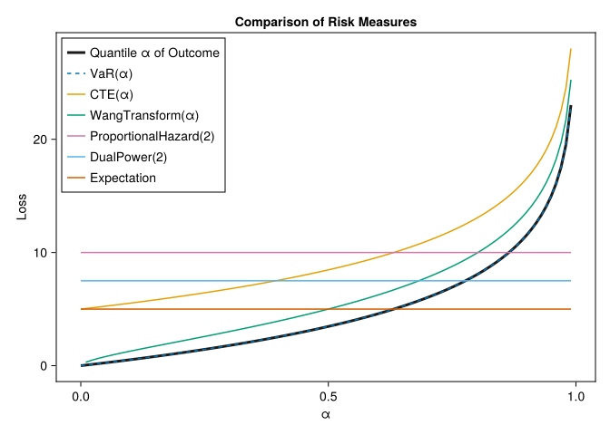

```julia
using Distributions, Random, ActuaryUtilities, CairoMakie

# the assumed distribution of outcomes
outcomes = Weibull(1, 5)

Random.seed!(2024)

αs = range(0.0, 0.99; length=100)

let
    f = Figure()
    ax = Axis(
        f[1, 1],
        xlabel="α",
        ylabel="Loss",
        title="Comparison of Risk Measures",
        xgridvisible=false,
        ygridvisible=false,
    )

    lines!(
        ax,
        αs,
        [quantile(outcomes, α) for α in αs],
        label="Quantile α of Outcome",
        color=:grey10,
        linewidth=3,
    )

    lines!(
        ax,
        αs,
        [VaR(α)(outcomes) for α in αs],
        label="VaR(α)",
        linestyle=:dash
    )
    lines!(
        ax,
        αs,
        [CTE(α)(outcomes) for α in αs],
        label="CTE(α)",
    )
    lines!(
        ax,
        αs[2:end],
        [WangTransform(α)(outcomes) for α in αs[2:end]],
        label="WangTransform(α)",
    )
    lines!(
        ax,
        αs,
        [ProportionalHazard(2)(outcomes) for α in αs],
        label="ProportionalHazard(2)",
    )

    lines!(
        ax,
        αs,
        [DualPower(2)(outcomes) for α in αs],
        label="DualPower(2)",
    )
    lines!(
        ax,
        αs,
        [RiskMeasures.Expectation()(outcomes) for α in αs],
        label="Expectation",
    )
    axislegend(ax, position=:lt)

    f
end
```

### 15.4.2 Variance Reduction Techniques

While Monte Carlo simulation is a powerful approach for modeling complex financial or actuarial systems, it can require a very large number of random draws for the results to converge. When there has been a limited number of runs, the variance of the sampled results can be high and vary materially between different sets of stochastic runs. This can be addressed by simply running more scenarios, but can be computationally expensive, particularly when path-dependent processes—or high-dimensional models—are involved. For this reason, several “variance reduction techniques” have been established to improve efficiency without reducing accuracy. They work by designing the way we draw samples (or process them) so that desired statistics converge more quickly.

#### 15.4.2.1 Control Variates

A control variate is a random variable whose expected value is already known (or can be estimated with high precision). By simulating the main process alongside the control variate and leveraging the differences in outcomes, the overall variance of the estimator is reduced. In finance, for instance, one might use a simpler instrument whose price is analytically known as a control variate when simulating a more complex derivative.

#### 15.4.2.2 Antithetic Variates

In antithetic variates, each random draw ($X$) is paired with a corresponding draw ($-X$) or another symmetric transformation. The idea is that positive and negative deviations tend to cancel out, thereby reducing overall variability. For example, if simulating geometric Brownian motion paths, each path with a particular series of random shocks could be matched with a path using the same shocks negated. Updating estimates with the average result of these pairs generally yields a lower variance for the same number of total draws.

#### 15.4.2.3 Stratified Sampling

In stratified sampling, instead of sampling purely at random across the entire probability distribution, the distribution is divided into “strata” (or sub-intervals), and draws are forced to fall into each of these strata with a pre-specified frequency. By covering the distribution more systematically, the resulting estimates often converge faster. A related approach is **quasi-Monte Carlo**, which uses deterministic low-discrepancy sequences (such as Sobol or Halton sequences) to span the sample space more uniformly than random sampling. Julia has a package for this called QuasiMonteCarlo.jl.

Together, these techniques reflect a crucial principle of computational thinking: by leveraging structure or known properties of the simulation, you can achieve more accurate estimates with fewer overall scenarios. This translates into faster runs, less strain on computational resources, and better performance when embedding these methods in large-scale models or iterative processes.

### 15.4.3 Stochastic Modeling: Examples

#### 15.4.3.1 Macroeconomic Analysis

Here we show a stochastic process used in macroeconomic analysis. Stochastic macroeconomic analysis often involves modeling random shocks and their effects on macroeconomic variables such as output, consumption, inflation, and employment. One common approach is through Dynamic Stochastic General Equilibrium (DSGE) models, which are widely used in macroeconomic analysis. These models incorporate randomness (stochastic elements) to capture real-world uncertainty in economic systems. Below, we simulate a simpler relative of these models: a Solow growth model (in per-effective-worker terms) with random productivity shocks.

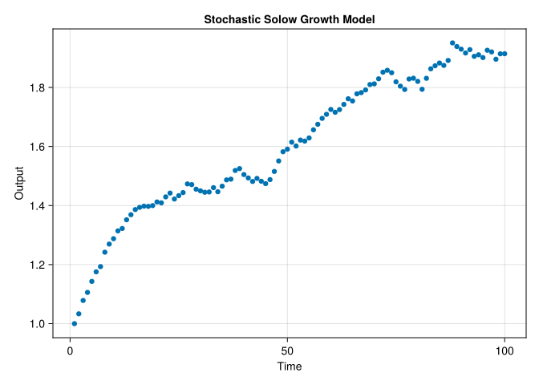

```julia
using Random, CairoMakie, Distributions

# Parameters
α = 0.33                # Capital share of output
δ = 0.05                # Depreciation rate
s = 0.2                 # Savings rate
n = 0.01                # Population growth rate
g = 0.02                # Technology growth rate
σ = 0.01                # Standard deviation of productivity shocks
T = 100                 # Number of periods to simulate
K0 = 1.0                # Initial capital stock
A0 = 1.0                # Initial productivity

# Random number generator (Xoshiro as default with a seed to ensure reproducibility)
rng_gen = Xoshiro(1234)

# Function to simulate the model
function simulate_stochastic_solow(rng, T, α, δ, s, n, g, σ, K0, A0)
    # Shock distribution (normal distribution for productivity shocks)
    shock_distribution = Normal(0, σ)
    K = zeros(T)        # Capital (per effective worker) over time
    Y = zeros(T)        # Output (per effective worker) over time
    A = zeros(T)        # Productivity shocks over time
    A[1] = A0           # Initial productivity
    K[1] = K0           # Initial capital

    for t in 1:(T-1)
        # Apply random productivity shock
        ε_t = rand(rng, shock_distribution)
        A[t+1] = A[t] * exp(ε_t)  # Productivity evolves stochastically

        # Output based on Cobb-Douglas production function
        Y[t] = A[t] * K[t]^α

        # Capital accumulation equation
        K[t+1] = s * Y[t] + (1 - δ) * K[t]

        # Population and technology growth dilute capital per effective worker
        K[t+1] /= (1 + n) * (1 + g)
    end

    Y[T] = A[T] * K[T]^α  # Final output
    return K, Y, A
end

# Simulate the model
K, Y, A = simulate_stochastic_solow(rng_gen, T, α, δ, s, n, g, σ, K0, A0)

# Plot the results
f = Figure()
axis = Axis(
    f[1, 1],
    xlabel="Time",
    ylabel="Output",
    title="Stochastic Solow Growth Model"
)
scatter!(1:T, Y, label="Output (Y)")
f
```

#### 15.4.3.2 Other Examples

Stochastic examples can be found in many other sections of this book, such as:

- Portfolio optimization applications (Chapter 27).
- Genetic algorithms for certain optimization problems (Chapter 17).
- Stochastic state-based mortality projections (Chapter 30).

## 15.5 Pseudo-Random Number Generators

Modern computers use pseudo-random number generators (PRNGs)—algorithms that produce sequences of numbers that appear random but are actually determined by an initial seed. Given the same seed, you get the same sequence. PRNGs also have a finite period: after enough generated values, the sequence repeats. Choose PRNGs with periods that are long enough for your application.

Financial modelers should understand how PRNGs work because many financial models rely on Monte Carlo simulations, risk analysis, and other stochastic modeling techniques that require random sampling. A good PRNG is essential for robust financial modeling. Choosing the right PRNG ensures results with high statistical quality and efficiency, which are critical when making financial decisions. The ability to specify and control the seed of a random number generator is a fundamental requirement in computational modeling, as it enables exact reproducibility of results. By using a fixed seed, simulations can be rerun with identical random sequences, allowing researchers and stakeholders to verify outcomes, conduct consistent sensitivity analyses, and perform rigorous debugging. This reproducibility is critical for transparency, auditability, and compliance with regulatory standards in fields such as quantitative finance, risk management, and scientific computing. Without a seedable PRNG, the inherent randomness of simulations would preclude the possibility of replicating results precisely, undermining confidence in the validity and reliability of the modeling process.

Different choices of random number generators typically have low impact on the mean outputs of stochastic models, since most generators are designed to approximate uniform distributions adequately. However, they can have substantial effects on risk measures such as standard deviation, Value-at-Risk (VaR), and tail quantiles, particularly when the PRNG has a short period or exhibits hidden correlations. In such cases, the variability and uncertainty estimates around risk measures can be severely biased or understated, leading to misleading conclusions about the model’s risk profile. For this reason, it is essential to rerun the stochastic model multiple times with different seeds—or even different PRNGs—to test the stability and convergence of the estimated risk measures and ensure that the results are robust to the choice of random number source.

### 15.5.1 Common PRNGs

#### 15.5.1.1 Mersenne Twister

For many years, the Mersenne Twister was a standard and highly recommended PRNG for financial modeling purposes. One of its greatest strengths is its exceptionally long period of $2^{19937} - 1$, which is crucial for applications requiring a large number of independent random numbers. It is also known for its good statistical properties, passing many standard tests for randomness. Moreover, it was designed with features for creating multiple streams, though ensuring their statistical independence in parallel applications requires careful management.

#### 15.5.1.2 Xorshift

Xorshift is a family of PRNGs known for their simplicity and extremely fast operation. The name “Xorshift” comes from the bitwise XOR (exclusive or) and bit-shifting operations that are the core of the algorithm. Xorshift generators are often used in applications where speed is a priority and cryptographic-strength randomness is not a strict requirement. One of the main advantages of xorshift is that its core operations can be efficiently implemented in hardware. However, a typical xorshift generator has a relatively short period compared to the Mersenne Twister.

#### 15.5.1.3 Xoshiro

Xoshiro is a family of high-performance PRNGs with excellent statistical properties. The name “Xoshiro” is a portmanteau of the core operations it uses: XOR, shift, and rotate. Xoshiro algorithms, including the highly-regarded **Xoshiro256++** variant, use a combination of bitwise XOR, bit-shifting, and addition/rotation operations. They generally have more complex update rules and longer periods than basic Xorshift algorithms.

When selecting seeds at random to initialize multiple instances of the Mersenne Twister generator, there is a significant likelihood of producing streams that are statistically correlated in parallel computations. This arises because the default seeding mechanism may not sufficiently de-correlate the internal states across different instances. In contrast, generators such as Xoshiro256++ offer markedly improved suitability for parallel environments, with carefully managed methodologies for ensuring stream independence.

#### 15.5.1.4 Comparing PRNGs

| Generator | Typical Period | Relative Speed | Parallel Safety |
| --- | --- | --- | --- |
| Mersenne Twister | Very Long ($2^{19937}-1$) | Good | Poor (risk of correlation) |
| Xorshift | Shorter | Very Fast | Poor (not designed for it) |
| Xoshiro256++ | Very Long ($2^{256}-1$) | Excellent | Excellent (designed for it) |

**Note**

Since Julia 1.7, the default random number generator for the language has been Xoshiro256++, which replaced an implementation of Mersenne Twister.

Importantly, Julia’s implementation of Xoshiro256++ is thread-safe (meaning you can use the RNG in multiple threads without losing RNG quality).

### 15.5.2 Consistent Interface

Julia offers a consistent interface for random numbers due to its design and multiple dispatch principles. Consider the following random numbers in different data types.

```julia
using Random

rng = MersenneTwister(1234)
rand(rng, Int, (2, 3))
```

```
2×3 Matrix{Int64}:
 7022509616038853369  -483142612144439943  -9189440298257092269
 4512210966853297707  3016561889232165636  -2139829978692188285
```

```julia
using Random

rng = MersenneTwister(1234)
rand(rng, Float64, (2, 3))
```

```
2×3 Matrix{Float64}:
 0.538321  0.0275419  0.115857
 0.997355  0.0703632  0.905544
```

```julia
using Random

rng = Xoshiro(1234)
rand(rng, Bool, (2, 3))
```

```
2×3 Matrix{Bool}:
 1  0  1
 0  1  1
```

Passing the RNG explicitly is a good habit; it guarantees reproducibility, keeps multi-threaded simulations thread-safe, and makes it trivial to swap PRNG families when performing robustness checks.

## 15.6 Conclusion

Stochastic modeling studies systems influenced by random factors and uncertainty. By combining random variables, probability distributions, and processes like Markov chains or Brownian motion, these models provide insights into systems that can’t be described deterministically.

Balbás, Alejandro, José Garrido, and Silvia Mayoral. 2009. “Properties of Distortion Risk Measures.” *Methodology and Computing in Applied Probability* 11 (3): 385–99. https://doi.org/10.1007/s11009-008-9089-z.

Hardy, Mary R. 2006. “An Introduction to Risk Measures for Actuarial Applications.” *SOA Syllabus Study Note* 19.

Wang, Shaun S. 2002. “A Universal Framework for Pricing Financial and Insurance Risks.” *ASTIN Bulletin* 32 (2): 213–34. https://doi.org/10.2143/AST.32.2.1027.

[^1]: Kalos was a pioneer in Monte Carlo techniques, quoted via https://doi.org/10.1007/978-3-540-74686-7_3
[^2]: An extended example of this approach is discussed in Chapter 25.
[^3]: A worked example of this approach is illustrated in Chapter 30.